# Week 5: Text mining 3

SECU0050

Bennett Kleinberg

13 Feb 2020

Data Science for Crime Scientists

## Week 5: Text mining 3

## Today

- text similarity
- intro to word embeddings

What makes two strings similar?

## Factors in similarity

- lexical similarity
- phonetic similarity
- semantic similarity

Underlying challenge: **quantification**

## String similarity

- Levenshtein distance
- Damerau-Levenshtein distance
- q-gram distances

*Aim: numerical measure of distance*

```r
string_a = 'crime'
string_b = 'criminal'
```

How much do these two differ?

## Levenshtein’s approach

Distance between $A$ and $B$:

1. change $A$ to obtain $B$
2. allowed edits:
   - substituting characters
   - adding characters

## Lev(‘crime’, ‘criminal’)

1. crim<sub>e</sub>**i**
2. crimi**n**
3. crimin**a**
4. crimina**l**

4 edits are required to change ‘crime’ into ‘criminal’.

## In R

```r
library(stringdist)

stringdist(a = 'crime'
           , b = 'criminal'
           , method = 'lv')
```

```
## [1] 4
```

$Lev_{(crime, criminal)} = 4$

## Your turn

Pair 1:

- A = “london”
- B = “amsterdam”

Pair 2:

- C = “london”
- D = “condom”

```r
stringdist(a = 'london'
           , b = 'amsterdam'
           , method = 'lv')
```

```
## [1] 8
```

```r
stringdist(a = 'london'
           , b = 'condom'
           , method = 'lv')
```

```
## [1] 2
```

## Multi-word phrases

- A = “new york”
- B = “manhattan”

```r
stringdist(a = 'new york'
           , b = 'manhattan'
           , method = 'lv')
```

```
## [1] 9
```

## Converting distances to similarity

1. calculate distance $dist$ (e.g. $Lev_{(crime, criminal)} = 4$)
2. calculate maximum distance $\max dist$
3. obtain quotient of $\frac{dist}{\max dist}$
4. substract quotion from 1: $sim = 1 - \frac{dist}{\max dist}$

## Distance to similarity

1. $Lev_{(crime, criminal)} = 4$
2. $\max Lev_{(crime, criminal)} = 8$
3. $\frac{Lev_{(crime, criminal)}}{\max Lev_{(crime, criminal)}} = \frac {4}{8}$
4. $1 - \frac{Lev_{(crime, criminal)}}{\max Lev_{(crime, criminal)}}$

$1 - \frac{4}{8} = 0.5$

## Using `stringsim(...)`

```r
stringsim(a = 'crime'
           , b = 'criminal'
           , method = 'lv')
```

```
## [1] 0.5
```

## q-grams

- essentially: n-grams on character-level

```r
qgrams('crime', 'criminal', q = 2)
```

```
##    cr ri im me mi na in al
## V1  1  1  1  1  0  0  0  0
## V2  1  1  1  0  1  1  1  1
```

## Setting q

Note that $q$ is anaolgous to $n$ in n-grams:

```r
qgrams('crime', 'criminal', q = 3)
```

```
##    cri rim ime imi min nal ina
## V1   1   1   1   0   0   0   0
## V2   1   1   0   1   1   1   1
```

## q-grams for string distance

Simple approach: absolute difference

```r
stringdist(a = 'crime'
           , b = 'criminal'
           , method = 'qgram'
           , q = 3)
```

```
## [1] 5
```

## q-gram distance here?

```r
stringdist(a = 'london'
           , b = 'condom'
           , method = 'qgram')
```

*For q = 2!*

```r
qgrams('london', 'condom', q = 2)
```

```
##    lo on nd om do co
## V1  1  2  1  0  1  0
## V2  0  1  1  1  1  1
```

```r
stringdist(a = 'london'
           , b = 'condom'
           , method = 'qgram'
           , q = 2)
```

```
## [1] 4
```

## Distances between vectors

Suppose we have got two vectors:

- $\vec{v_1} = [1, 2]$
- $\vec{v_2} = [4, 3]$

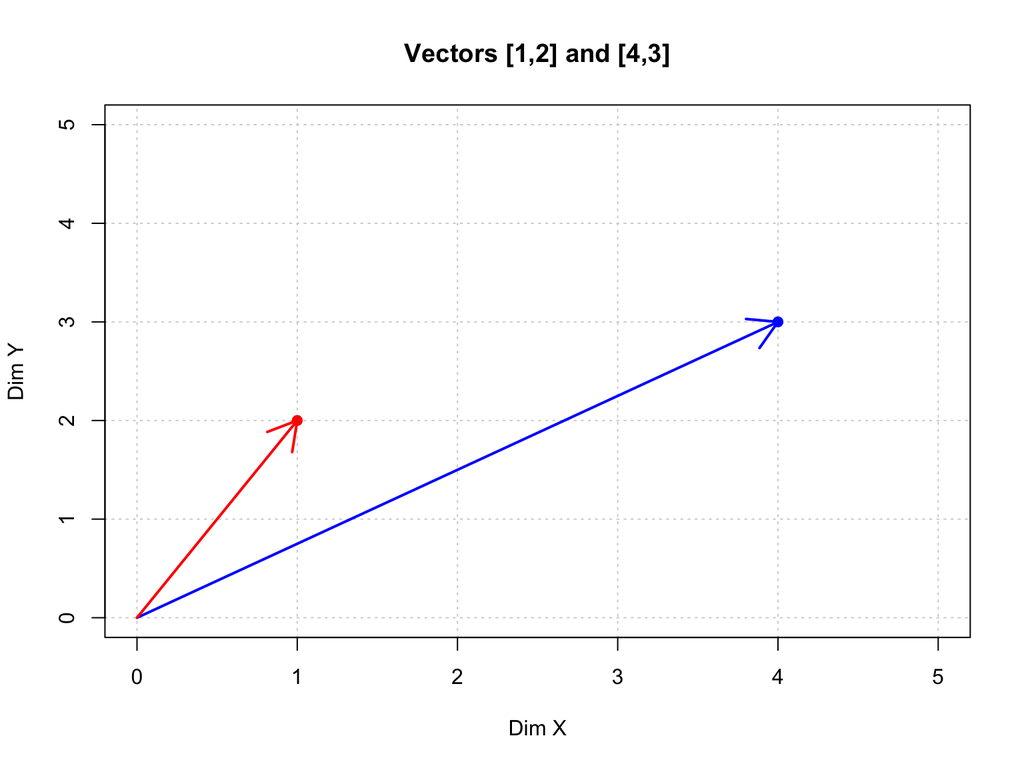

## Euclidean distance

Uses Pytharogean theorem.

For two two-dimensional locations:

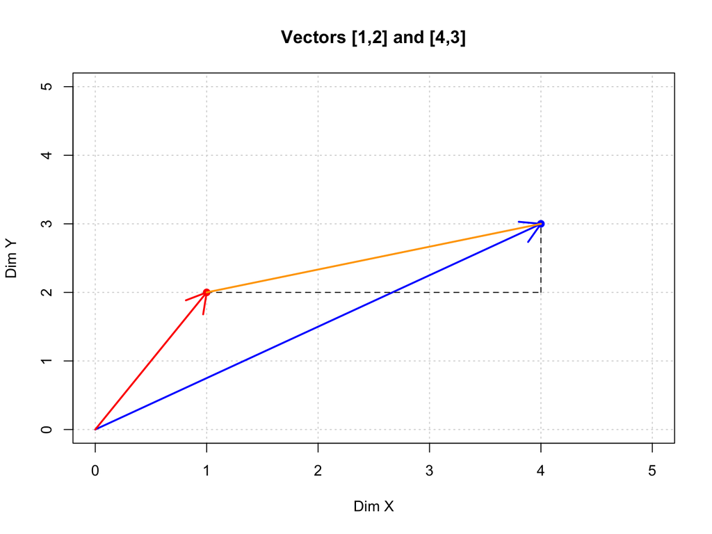

## By hand:

- $a = x_2 - x_1 = 4 - 1 = 3$
- $b = y_2 - y_1 = 3 - 2 = 1$
- $c^2 = a^2 + b^2$

Thus:

$c = \sqrt{a^2 + b^2} = \sqrt{9 + 1} = 3.16$

## Euclidean distance in 3 dimensions

$dist(A, B) = \sqrt{(A_1 - B_1)^2 + (A_2 - B_2)^2 + (A_3 - B_3)^2}$

## On the q-grams

```r
qgrams('london', 'condom', q = 2)
```

```
##    lo on nd om do co
## V1  1  2  1  0  1  0
## V2  0  1  1  1  1  1
```

## Vectors V1 and V2

```r
matrix_1 = matrix(data = c(c(1,2,1,0,1,0),c(0,1,1,1,1,1))
                  , nrow = 2, byrow = T)

dist(matrix_1, method = 'euclidean')
```

```
##   1
## 2 2
```

## Euclidean distance and magnitude

- takes into account the magnitude of vectors
- but this is not always meaningful
- different metric: *cosine* distance

## Cosine distance

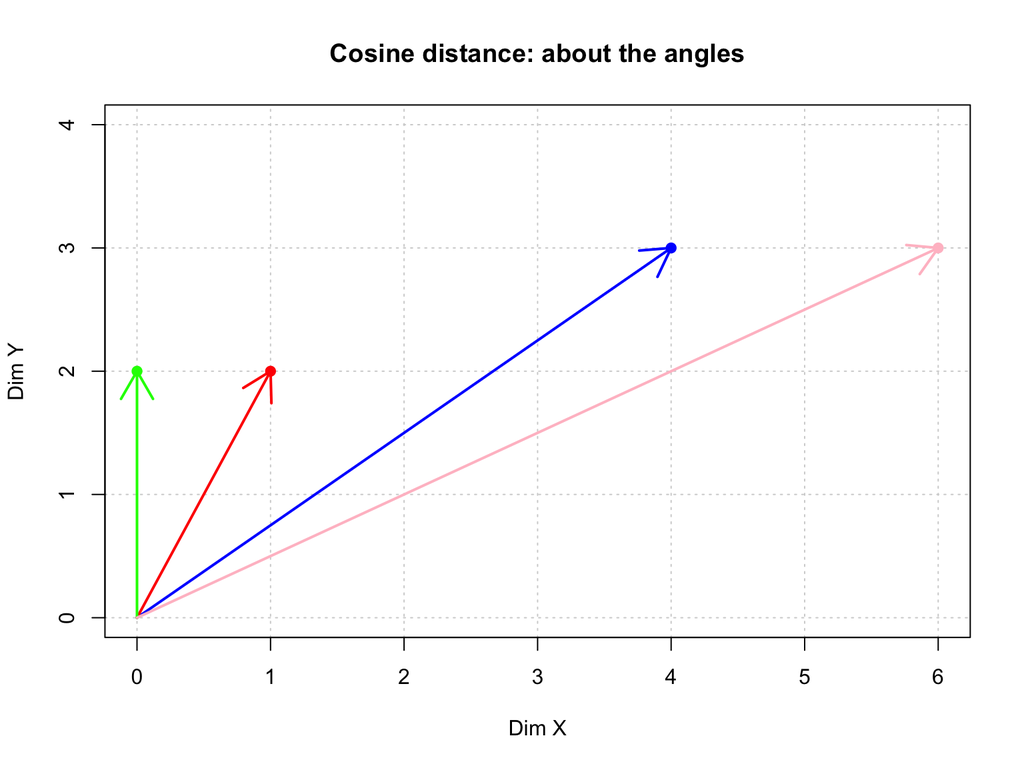

## Cosine similarity

$csim = \frac{A \times B}{\sqrt{A \times A} * \sqrt{B \times B}}$

_Note: $A \times B$ is the dot product of the vector.

## In R

```r
V1 = c(4,2,3)
V2 = c(1,3,1)

cossim = function(A, B){
  numerator = sum(A*B)
  denominator = sqrt(sum(A*A))*sqrt(sum(B*B))
  cosine_sim = numerator/denominator
  return(cosine_sim)
}

cossim(V1, V2)
```

```
## [1] 0.7278603
```

## Cosine similarity on q-grams

```r
qgrams('london', 'condom', q = 2)
```

```
##    lo on nd om do co
## V1  1  2  1  0  1  0
## V2  0  1  1  1  1  1
```

```r
stringsim('london', 'condom', q = 2, method = 'cosine')
```

```
## [1] 0.6761234
```

## Similarity of phrases

```r
phrase_1 = "I think numbers are great"
phrase_2 = "Numbers are useless"

stringsim(phrase_1, phrase_2, q=3, method = 'cosine')
```

```
## [1] 0.4551496
```

## Problems with lexical similarity?

## Consider these

```r
[sand, beach]
[water, sea]
[bank, money]
[euro, dollar]
```

## What about the semantic dimension?

- lexical dimension doable
- But what about the meaning of words?
- “sand” and “beach” are close to one another
- … but lexical metrics fail to uncover this

## Semantic similarity

If a method can do this, then we expect:

- $cossim(sand, beach) > cossim(bleach, beach)$
- $cossim(euro, dollar) > cossim(neuro, euro)$

## Word embeddings

- meaning of words determined by information associated with it
- computationally: we express each word as a vector
- that vector contains the information associated with the word

Does that work? When?

## Vectors are everywhere

“these are word embeddings”

| document | these | are | word | embeddings |
| --- | --- | --- | --- | --- |
| text1 | 1 | 0 | 0 | 0 |
| text2 | 0 | 1 | 0 | 0 |
| text3 | 0 | 0 | 1 | 0 |
| text4 | 0 | 0 | 0 | 1 |

Every word is a vector (called: **a one-hot vector**)

## Every document is a vector

| document | career | upon | which | i | am | about | to | enter | appear | fellow | citizens |
| --- | --- | --- | --- | --- | --- | --- | --- | --- | --- | --- | --- |
| 1825-Adams | 2 | 16 | 27 | 15 | 4 | 1 | 101 | 1 | 1 | 3 | 2 |
| 1829-Jackson | 0 | 0 | 12 | 12 | 0 | 1 | 53 | 0 | 1 | 2 | 2 |
| 1833-Jackson | 0 | 5 | 14 | 6 | 2 | 1 | 46 | 0 | 0 | 3 | 3 |

## Vector-based word similarity

So can’t we just calculate the vector similarity then? (e.g. cosine similarity)

Ideas?

## Problem of sparsity

Remember: dot products!

Dot product of two one-hot vector is always zero.

## Embedding a vector

- we want a denser representation of each word
- two approaches:
  - word2vec: $P(word|context)$ and $P(context|word)$
  - glove: corpus co-occurrences
  - Details available [here](https://github.com/maximilianmozes/word_embeddings_workshop_resources/blob/master/slides/theo.pdf)

## Embeddings: aim

From high-dimensional vector space to lower dimensional space.

E.g. from a one-hot vector of size 10,000 to an embeddeding of size 300.

## Properties of word embeddings

- we have an embedding of each word
- that captures some kind of “context”
- each embedding in a given model has the same length

## Using word embeddings

- no need to build the embeddings
- typically we use pre-trained models (e.g. from Google, Facebook)
- e.g. [Word vectors for 157 languages](https://fasttext.cc/docs/en/crawl-vectors.html) and the [Glove embeddings](https://nlp.stanford.edu/projects/glove/)
- we can then retrieve the embeddings for a given word

## In R

*Note: heavy on your RAM (loads massive file into memory)*

1. initialising pre-trained models
2. calculating similarity between terms

Code: https://github.com/ben-aaron188/r_helper_functions/blob/master/init_glove.R

## Initialise Glove

```r
init_glove(dir = './glove', which_model = '6B', dim=100)
```

```r
[1] "Looking for pretrained GloVe vectors in: /Users/bennettkleinberg/Documents/glove"
[1] "Success - found GloVe objects in directory."
[1] "--- initialising the 100d model ---"
[1] "Success: initialised GloVe model as glove.pt"
```

We now have the model available to us.

`glove.pt`

## Working with word embeddings

```r
cos_sim_vals = textstat_simil(glove.pt
                              , selection = c("man", "cat")
                              , margin = "documents"
                              , method = "cosine")
```

## Assess embedding distances

```r
head(sort(cos_sim_vals[,1], decreasing = TRUE), 10)
```

Output similar to:

```r
      man     woman       boy       one    person   another       old
1.0000000 0.8323494 0.7914871 0.7788749 0.7526816 0.7522236 0.7409117
     life    father    turned
0.7371697 0.7370323 0.7347695
```

## Looking at word embeddings

```r
cat_emb = as.vector(glove.pt[row.names(glove.pt) == 'cat', ])
```

```r
  [1]  0.2308800  0.2828300  0.6318000 -0.5941100 -0.5859900  0.6325500
  [7]  0.2440200 -0.1410800  0.0608150 -0.7898000 -0.2910200  0.1428700
 [13]  0.7227400  0.2042800  0.1407000  0.9875700  0.5253300  0.0974560
 [19]  0.8822000  0.5122100  0.4020400  0.2116900 -0.0131090 -0.7161600
 [25]  0.5538700  1.1452000 -0.8804400 -0.5021600 -0.2281400  0.0238850
 [31]  0.1072000  0.0837390  0.5501500  0.5847900  0.7581600  0.4570600
 [37] -0.2800100  0.2522500  0.6896500 -0.6097200  0.1957800  0.0442090
 [43] -0.3113600 -0.6882600 -0.2272100  0.4618500 -0.7716200  0.1020800
 [49]  0.5563600  0.0674170 -0.5720700  0.2373500  0.4717000  0.8276500
 [55] -0.2926300 -1.3422000 -0.0992770  0.2813900  0.4160400  0.1058300
 [61]  0.6220300  0.8949600 -0.2344600  0.5134900  0.9937900  1.1846000
 [67] -0.1636400  0.2065300  0.7385400  0.2405900 -0.9647300  0.1348100
 [73] -0.0072484  0.3301600 -0.1236500  0.2719100 -0.4095100  0.0219090
 [79] -0.6069000  0.4075500  0.1956600 -0.4180200  0.1863600 -0.0326520
 [85] -0.7857100 -0.1384700  0.0440070 -0.0844230  0.0491100  0.2410400
 [91]  0.4527300 -0.1868200  0.4618200  0.0890680 -0.1818500 -0.0152300
 [97] -0.7368000 -0.1453200  0.1510400 -0.7149300
```

## Our expectations (1)

$cossim(sand, beach) > cossim(bleach, beach)$

```r
sand_emb = as.vector(glove.pt[row.names(glove.pt) == 'sand', ])
beach_emb = as.vector(glove.pt[row.names(glove.pt) == 'beach', ])
bleach_emb = as.vector(glove.pt[row.names(glove.pt) == 'bleach', ])
```

```r
cossim(sand_emb, beach_emb)

#[1] 0.5469368
```

```r
cossim(beach_emb, bleach_emb)

#[1] -0.0501422
```

## Our expectations (2)

$cossim(euro, dollar) > cossim(neuro, euro)$

```r
euro_emb = as.vector(glove.pt[row.names(glove.pt) == 'euro', ])
dollar_emb = as.vector(glove.pt[row.names(glove.pt) == 'dollar', ])
neuro_emb = as.vector(glove.pt[row.names(glove.pt) == 'neuro', ])
```

```r
cossim(euro_emb, dollar_emb)
#[1] 0.7328042

cossim(euro_emb, neuro_emb)
#[1] -0.08723018
```

## Arithmetics with word embeddings

What if we could do maths with meaning?

Do semantic relationships hold true in embeddings?

## BERLIN - GERMANY + FRANCE

If: $\vec{BERLIN} \approx BERLIN$

$\frac{\vec{GERMANY}}{\vec{BERLIN}} :: \frac{\vec{FRANCE}}{\vec{?}}$

```r
berlin = as.vector(glove.pt[row.names(glove.pt) == 'berlin', ])
germany = as.vector(glove.pt[row.names(glove.pt) == 'germany', ])
france = as.vector(glove.pt[row.names(glove.pt) == 'france', ])
```

```r
mystery_1 = berlin - germany + france

  [1]  0.5129700 -0.7331210 -0.1134250  0.4532580  0.5920800  0.5046900
  [7]  0.1716500  0.6980830  0.0461335  0.2364360 -0.2775940 -0.0869580
 [13] -0.2696400  0.1602300 -0.9382800  0.3996800  0.1305250 -0.6906400
 [19] -0.6324500 -0.3029900  0.2935000  0.1269000 -0.1562700 -1.1325400
 [25]  ...
```

## Clostest neighbours to the mystery vector?

```r
head(sort(cos_sim_vals[,1], decreasing = TRUE), 10)

 mystery_1      paris     france     french prohertrib     berlin   brussels
 1.0000000  0.8827144  0.7558026  0.7075165  0.6943174  0.6665562  0.6574431
      lyon     london         le
 0.6526201  0.6407975  0.6403628
```

## KING - MAN + WOMAN

$\frac{\vec{MAN}}{\vec{KING}} :: \frac{\vec{WOMAN}}{\vec{?}}$

```r
head(sort(cos_sim_vals[,2], decreasing = TRUE), 10)

  mystery_2      king     queen   monarch    throne  daughter    prince  princess
1.0000000 0.8551837 0.7834414 0.6933802 0.6833110 0.6809082 0.6713142 0.6644083
   mother elizabeth
0.6579325 0.6563301
```

## Why does this work?

Possible explanation: **the distributional hypothesis** (Harris, 1954)

*Words in that occur in the same context have the same meaning.*

## Cautionary note

Word embeddings are very powerful, but:

- [instable](https://www.aclweb.org/anthology/N18-1190.pdf)
- numerically meaningless
- [Limitations of word embeddings, Burdick (2019)](https://github.com/maximilianmozes/word_embeddings_workshop_resources/blob/master/slides/limitations.pdf)

(see the required reading for today)

## What’s next?

- Today’s tutorial: text similarity, word embeddings
- Homework: more word embeddings, custom functions

Next week: reading week (then: Machine Learning 1)